# Work Comp Experience Rating papers

Gillam, Gillam & Snader 1, NCCI 1, Venter

August 06, 2016

## Cliff’s Summary

### Gillam

Off-balance

Experience rating goals

Plan parameters

Know the 3 tests + 1 criteria:

- Dorweiler
  - Sort $\rightarrow$ group $\rightarrow$ subdivision
  - Know the reasonings and meaning of trendings
- Quintiles
  - Sort $\rightarrow$ group $\rightarrow$ 5 quintiles
- Efficiency
  - No sort no group
- Dorweiler’s Criterion
- Quintiles and efficiency can only be used when comparing 2 or more plans

### Venter

Rationales for split plans and various NCCI modifications

Dorweiler test

Different iterations of the NCCI plans

- All the changes and purpose
- Assumptions on the $B$ and $K$

Purpose of experience rating

### Gillam & Snader 1

General credibility properties

General credibility formula explanation

### NCCI 1

Using the NCCI table and everything related

- Get $A_p$ and $A_e$, know what dates are covered
- Look up per claim, multiple claim
  - Also have a disease loss but limit is for PY
- Make sure we use the 2011 table (there’s a 2010)
- Know the process of geting each parameters
- Qualification of Exp Mod (2.A.2.)

Experience vs Schedule

How the formula stabilize the exp rating

- Various limits
- More weight for larger risk

## Types of Exam Questions

### Gillam

Plan Parameters

- 2002 Q32 $\star$ (SRP, G)
- 2006 Q25 $\star$ (SRP and definition)

Off-balance

- 2000 Q41
- 2001 Q28
- 2002 Q10 (reasons off-balance < 1)
- 2003 Q6
- 2004 Q15
- 2004 Q42 (Explainations of off balance)
- 2006 Q26 $\star$ (calculate, explain)
- 2007 Q29 $\star$ (c is talking about steady state)
- 2008 Q22
- 2009 Q25
- 2010 Q22
- 2011 Q13 $\star$ (Don’t forget the non experience rated class)
- 2013 Q10 $\star$ (Detailed explainations)
- 2013 Q11 $\star$
- 2005 Q26c (grouped under Gilliam)
- 2012 Q16

Tests:

- 2003 Q26 $\star$ (Efficiency, but can do any)
- 2006 Q23 $\star$ (Purpose of Dorweiler’s tests)
- 2008 Q23 $\star$ (Quintile test)
- 2009 Q23 $\star$ (Dorweiler and interpretation)
- 2010 Q23 $\star$ (Dorwiler and mod calculations)
- 2011 Q16 $\star$ (Quintiles, no premium)

Concepts:

- 2001 Q5 (purpose, ELR Dratios, )
- 2009 Q20 (purpose of Exp rating, VHM and credibility)
- 2011 Q16 a (Dorweiler’s condition)

CALCULATING G, SRP, SACC

- Formula calc
- The SACC data should be trended from the midpoint of the last three years of unit plan data to the midpoint of the experience period
- G is calculated using losses used in experience rating, so technically there’s limit now after 1998 changes

### Venter

Dorweiler’s Test

- 2000 Q1
- 2004 Q16 (explain idea scenario)
- 2004 Q39 (look at trend or s.d. of LR)
- 2005 Q26 $\star$ (identify, trend)
- 2007 Q26
- 2012 Q16 $\star$ (Calculate from scratch)
- 2013 Q9 $\star\star$ (Calculate mod then test; how to improve)

Concepts

- 2000 Q3 (1991 Change, split plan advantage)
- 2001 Q6 (goals of exp rating)
- 2001 Q26 $\star$ (All historical and current NCCI plans)
- 2002 Q31 $\star\star$ (How to test one of the NCCI plan changes)
- 2004 Q40 $\star$ (Problem with no split)
- 2005 Q29 (Problem with no split)
- 2006 Q27 $\star$ (Goal of exp reating and judge)
- 2010 Q19 $\star$ (NCCI split plan, full cred conflict with goal)
- 2012 Q11 $\star$ (Talk about rating principle! Use goal to defend)
- 2012 Q16 $\star$ (Mod stigma)
- 2014 Q11 $\star$ ($B \: K$ related)

EVALUATING EXPERIENCE RATING PLANS

1. Do this for current and proposed group
2. Sort by mod in increasing order
3. Group into 5 quintiles (Or whatever the questions tell you like low and high)
4. Get standard and manual LR for each group
5. Do $\dfrac{\sigma^2(Standard \: LR)}{\sigma^2(Manual \: LR)}$
6. Lower statistic is better (Can tell something by just eye balling the spreads of manual and standard)

### Gillam & Snader 1

Plug and play

- 2000 Q4 (standard single split formula)

Concepts:

- 2000 Q40 $\star$ (Considtion for credility and then test if satisfy)
- 2000 Q43 (Change from multi split to single split from 61 to 91)
- 2003 Q28 $\star$ (Explain credibility formula in words; Z limits)
- 2011 Q15 $\star$ (Explain single split plan)

1961 PROGRAM: $M,\: A_P,\: W,\: Z$

- The formula for $W$ is a bit different

1991 PROGRAM: $M,\: AP,\: W$

- Standard Perryman’s

### NCCI 1

Calculations

- 2000 Q42 $\star$ (Premium with NCCI singple split from claims)
  - $A_p$, $A_e$: SAL, 30% med (not on syllabus anymore), cut off point
- 2002 Q33 $\star\star$
  - Lookup multi claim limit and the split between primary and XS
  - Lookup ELR and D-ratio with class code
  - Use E from $ELR \times Payroll$ to lookup W and B
  - Check maximum mod
  - Make sure we use the 2011 table
- 2003 Q27
  - Know what dates are covered
- 2005 Q27 a
- 2006 Q24
- 2007 Q25 a
- 2007 Q28
- 2008 Q25 $\star$ (full blown)
- 2009 Q21
- 2010 Q20
- 2014 Q9 $\star$ (loss free mod)

Concepts

- 2001 Q25 (Grouping entities)
- 2002 Q34 (Schedule vs exp)
- 2005 Q27 b (Schedule)
- 2007 Q25 b (inflation split point)
- 2012 Q13 $\star$ s(experience rating stability, talk about terrorism insurance)

STANDARD PREMIUM & MOD FACTOR,EXPERIENCE PERIOD, CAPPED LOSSES

- Just lookups

MULTI STATE MOD

- Note that you get the state B and W by the total E and then weight by state E

INTRA STATE MOD SINGLE STATE ALL OTHER STATES

- Intrastate you have to adjust for the fact that the total $\neq$ sum of all of it’s parts
- $\dfrac{Mod_{all} \times E_{all}}{Mod_{St} \times E_{St} + Mod_{AllxSt} \times E_{AllxSt}}$
- Get the state mod and times the factor

## Must Know Formulas

Plan Parameters

- $\text{Trended SACC} = \left( \dfrac{\sum\limits_{y=1}^3 \text{Inc'd Loss}_y}{\sum_{y=1}^3 \text{Claim Count}_y} \right) \times e^{rt}$
  - undeveloped uncapped (except 100K cap for employers liability)
- $SRP = 250 \times \text{Trended SACC}$
  - Rounded to 5,000
- $SAL = 10\% \times SRP$
- $G = \dfrac{SRP}{250{,}000}$

Single split credibility formula

$Mod = \dfrac{A_p + W A_e + (1 - W)E_e + B}{E_{total} + B}$

## Purpose of Experience Rating

Relates an insured’s premium for $policy_t$ to their own loss experience from $policy_{t-1}$

$\begin{array}{lcccc} \text{Standard Premium} &= &\textbf{Modified Premium} &\times &\text{Schedule Mod Factor} \\ &= &\left( \textbf{Manual Premium} \times \textbf{Experience Mod Factor} \right) &\times &\text{Schedule Mod Factor} \\ \end{array}$

Mostly just assumes Sch Mod = 1 $\therefore$ Standard Premium = Modified Premium

Experience rating is suitable for WC $\because$ lots of variations within a classification plan due to level of control over safety practices

Experience rating helps further **distinguish between risks within a classification for things that typically doesn’t have a separate rating for**, e.g. Compensation, variation in premise, operating processes, materials, managements, employee morale, claim consciousness, relation to the community, etc

**Credibility** of actual loss experience depends on:

- Size of the insured (e.g. payroll)
- $\sigma$ between the loss experience of risks within a classification
  - Experience rating is more useful when the class plan doesn’t sufficiently explain $\sigma$ in loss experience between risks

Experience modification is a prospective measure only

2003 Q6 Experience rating will attempt to equalize standard loss ratios across all risks, which will implicitly attempt to equalize standard loss ratios across classes. However, since it isn’t looking segmenting by classes directly, it will only be a partial correction

## Goals of Experience Ratings

Important Concepts

1. **Predictive accuracy** $\Rightarrow$ Individual risk equity  
   Degree of charge based on past experience should be the degree to which it is predictive of future losses $\Rightarrow$ Insureds charged more closely relates to their loss potential $\Rightarrow$ Ensures equity, rates not unfairly discriminatory
   - Individual rate equity means charging risks a rate that is commensurate with their loss exposure
2. **Safety incentive**  
   Give insured financial incentive for loss control
3. **Enhance market competition** Increase availability of insurance since experience rating helps guarantee an equal profit potential on all risks after the application of the experience mod

**Balance between 1. and 2.** since 2. will charge for all losses while 1. will only charge for non-random prior losses that are predictive of future loss potential

2012 Q11 The main goal of experience rating is individual risk equity. Experience rating recognizes that each risk has a different loss potential, so by modifying rates appropriately, the expected profit potential for each risk can be made equal. This ensures that equity is achieved and rates are not unfairly discriminatory. Otherwise, risks with lower loss potential within the class would subsidize other higher loss potential risks

## Types of Experience Rating Plans

Maximize predictive accuracy $\Rightarrow$ Minimize error between predicted and actual losses

Use $\mathrm{E}[error^2]$ since it’s solvable and penalizes large errors

Linearity constraint: E-mod has to be a linear function of losses

- Simplify math and make them more understandable

2014 Q9 NCCI uses loss only (no ALAE)

### No-split Plans

No subdivision of losses

$\begin{array}{llll} Mod &= \dfrac{\text{Modified Expected Losses}}{\text{Expected Losses}} &= \dfrac{ZA + (1-Z)E}{E} & \cdots (1) \\ & &= 1 + Z \left( \dfrac{A - E}{E} \right) & \cdots (2)\\ & &= \dfrac{A + K_E}{E + K_E} \\ \end{array}$

- **Credibility**: $Z = \dfrac{E}{E + K_E}$
- For formula $(2)$
  - 1 represents the manual rate
  - $(A-E)$ is the charge/credit for experience
  - $\frac{Z}{E}$ moderates the effect of any single large claims

Alternatively, from $(1) \times \frac{P}{P}$ you get the Surety Association Plans formula:

$Mod = (1 - Z) + Z \dfrac{P}{E} \times \dfrac{A}{P}$

- $P$: Standard Premium
- $(1-Z)$: Premium Modifier
- $Z \dfrac{P}{E}$: Adjusted Loss Modifier
- $\dfrac{A}{P}$: Adjusted Loss Ratio

#### Credibility Constant

$K_E$: Credibility Constant

$K_E$ could be:

- A constant; or
- $f(E)$; or
- Manually picked for desired responsiveness (NCCI)

Condition for $K_E$ (By relation for $Z$)

$E$ represents the size of risk

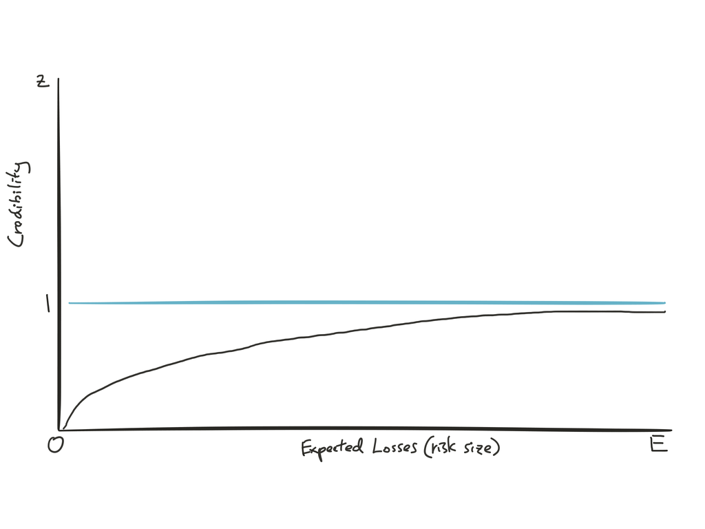

alt text

#### Problems of no split plans

Problematic for highly skewed, heavy-tailed distributions such as that of Work Comp claims

**Solution based on Venter’s Argument:**

Split losses into primary and XS, the dist<sup>n</sup> of each component becomes less heavy-tailed and more predictable than using unsplit losses

**Correct Argument:**

Splitting losses into primary and XS does NOT make each more predictable. E.g. it is much easier to price a ground-up policy than an excess policy, since there is much greater uncertainty around XS losses

Split plan works better because:

- Substantial parameter risk due to the claim count uncertainty that impacts mostly the primary layer
- Process risk is due to the volatility of severity that impacts mostly the XS layer
- Split plans are more effective when most of the parameter risk goes to one portion of the split while most of the process risk goes to a separate portion
- [Source](http://www.variancejournal.org/issues/?fa=article&abstrID=7015)

### Split Plans

Subdivision losses into *primary* and *XS* components and $\mathrm{E}[error^2]$ is minimized separately

**Primary:**

- Reflects claim frequency
- Receives most weight

**XS:**

- Reflects claim severity
- Losses are typcially capped to prevent large losses that are not predictive of future losses from having too big of an impact on the insured’s premium
  - e.g. the SAL in the NCCI plan

Memorize

$\begin{array}{llccc} Mod &= &\frac{1}{E}[Z_p A_p + (1-Z_p)E_p] &+ &\frac{1}{E}[Z_e A_e + (1-Z_e)E_e] \\ &= 1 + &Z_p \left( \dfrac{A_p - E_p}{E} \right) &+ &Z_e \left( \dfrac{A_e - E_e}{E} \right) \\ &= 1 + &\dfrac{A_p - E_p}{E + K_p} &+ &\dfrac{A_e - E_e}{E + K_e} \\ \end{array}$

- $Z_p = \dfrac{E}{E + K_p}; Z_e = \dfrac{E}{E + K_e}$

**Loss free mod formula:**

$\begin{array}{lccc} Mod &= &\frac{1}{E}[Z_p A_p + Z_e A_e] &+ &\frac{1}{E}[ (1-Z_p)E_p + (1-Z_e)E_e] \\ Mod &= &\frac{1}{E}[Z_p A_p + Z_e A_e] &+ &\text{loss-free mod} \\ \end{array}$

**Perryman’s First Formula:**

$Mod = \dfrac{A_p + W A_e + (1 - W)E_e + B}{E_{total} + B}$ Memorize

- $B = (1 - W)K > 0$
- $Z_p = \dfrac{E}{E + B}$
- $Z_e = W Z_p$
- Weight: $W = \dfrac{E + K_p}{E + K_e}$
  - $0 < W < 1$
  - $W$ never $\uparrow$ given $\downarrow$ $E$
  - For the 1961 NCCI it’s $W = \dfrac{\text{Expected Loss} - \text{Excess Cred. Threshold}}{\text{Full Cred. Threshold} - \text{Excess Cred. Threshold}}$
- $B = K_p$
- $E_{total} = E_p + W E_e + (1-W)E_e$
- Used by NCCI since 1940 change

#### Single Split Plans

$A_p = \begin{cases} A & A \leq C \\ C & A > C \\ \end{cases}$

$A_e = \hat{A} - A_p$

- $\hat{A}$: Capped loss that are too large that have no predictability
  - Cap by SAL

#### Multi-split Plans

Multiple incremental amounts of losses; Decreasing portion (by factor of $(1-d)^i$) of each successive increment is considered to be primary

$A_p = I + \sum\limits_{i=1}^{N-1}(1-d)^i I + (1-d)^N (A-NI)$

- $N$: number of complete increments
- $I$: incremental loss $
- $d$: rate of discount
- Max $A_p = \frac{I}{d}$

$A_e = \hat{A} - A_p$

## History of NCCI Experience Rating

| Time Period | Highlights |
| --- | --- |
| Pre-1940 | No-split |
| 1940 | Multi-split: $I = \$500, d = \frac{1}{3}$; $B$, $K$ $\downarrow$ linearly to risk size |
| 1961 | Single-split: @ $2,000 w/ max $A_p = \$10,000$ |
| 1991 | Single-split: @ $5,000 w/ max $A_p = \$5,000$; $B$, $K$, $\uparrow$ non-linearly to risk size |
| 1998 | $\downarrow$ Med-only weight; $\uparrow$ XS weight; inflation sensitive split |

### Pre-1940

No-split

$Mod = \dfrac{A + K_E}{E + K_E}$

### 1940 Changes

Multi-split

$Mod = \dfrac{A_p + W A_e + (1 - W)E_e + B}{E_{total} + B}$

- $I$ = $500
- $d$ = $\frac{1}{3}$

Tables of $B$ and $W$ based on risk size:

- Prevent large swings in E-mod for small insured
- $Z$ can be 1 for large insured

As risk size $\uparrow$:

- $B$, $K$, $\downarrow$
- $W$ $\uparrow$

### 1961 Changes

$A_p = \begin{cases} A & A \leq 2,000 \\ \dfrac{10,000A}{A + 8,000} & A > 2,000 \\ \end{cases}$

Max $A_p = 10,000$

$A_e = \hat{A} - A_p$

- $\hat{A}$ capped by max ratable value

### 1991 Changes

1. Simplified single split
2. $B$, $K$, $\uparrow$ non-linearly with premium
   - $W$ still $\uparrow$ with premium

$A_p = \begin{cases} A & A \leq 5,000 \\ 5,000 & A > 5,000 \\ \end{cases}$

$A_e = \hat{A} - A_p$

**Reason for change:**  
Too much credibility given to large risk and not enough for small risk $\Rightarrow$ <10K and >100K became preferred business

- Small risk with credit mod doesn’t get enough premium 2014 Q11

**Theoretically:**  
$B$, $K$ being constant assume that larger insureds are more stable than smaller insureds, and thus the variance of standard loss ratios should be inversely $\propto$ to risk size

**Reality:**  
Variance did not decrease that quickly

**Impact:**Important Memorize

| Small risks $Z_p$ | Small risks $Z_e$ |
| --- | --- |
| $\uparrow$ | $\uparrow; \: Z_e > 0$ |

| Large risks $Z_p$ | Large risks $Z_e$ |
| --- | --- |
| $\downarrow;\: max \: Z_p = 91\%$ | $\Downarrow;\: max \: Z_e = 57\%$ |

For large risk, $\because$ $Z_e \: \downarrow \: > Z_p \: \downarrow \: \Rightarrow$ Effectively gave primary losses more weight for large risks

New plan performed better for small and large risks, and performed equally well for medium sized risks based on quintiles test

2005 Q25 B and K being constant would assume that larger insureds are more stable than smaller insureds, and thus the variance of the standard loss ratio should be inversely proportional to risk size. Empirical studies have shown that variance does not decrease this quickly. As such, if B and K were constant, too much credibility would be given to large risks and not enough credibility would be given to small risks.

2010 Q19d Giving full credibility to loss experience conflicts with the goal of individual risk equity, which is to charge insureds for their true loss potential. Giving full credibility to an insured’s loss experience would penalize the insured for having random losses that do not reflect their true expected loss

### 1998 Change

Not in 2015 syllabus Concepts

1. $\downarrow$ $Z$ on Med-only by about 70%
   - Disincentivize not reporting med-only claims
   - Lowered ELRs and D-ratios to maintain balance
   - In practice it’s split into primary and excess first then only use 30% 2002 Q33
2. $\uparrow$ $Z_e$ as premium $\uparrow$
   - Promote safety incentive
3. Inflation sensitive split point

## Testing the Experience Rating Plan

Important know all test

Main challenge: Determining the proper $Z$ to give to prior losses

Correct $Z$ $\Rightarrow$ maximizing predictive accuracy of plan

### Dorweiler’s 2 conditions for correct credibility

Know

1. Necessary: $PLR_i = PLR_j \forall \: i,j$ credit and debit risks in prospective period (each random subgroup as well)
2. Sufficient: $\nexists \: \subset$ risks with $PLR_i \neq PLR_j$ in prospective period

3 test for predictive accuracy of the plan; All tests are performed for each size group separately

### Test 1: Dorweiler’s Test

**Setup:**

1. **Sort** risks by **mods** in **increasing** order
2. **Group** into subdivisions
3. For each subdivisions: calculate **manual** and **standard** LR using weighted averages by respective premium (w/ actual loss) Not super sure what to weight
   - If no premium: Manual LR $\Rightarrow$ Use $\dfrac{Loss_{Actual}}{Loss_{Expected}}$; Standard LR $\Rightarrow$ Use $\dfrac{Loss_{Actual}}{Loss_{Modified Expected}}$

**For plan performing ideally:**Know Concepts

- **Max dispersion** in manual LRs (**Identifies**)
  - Plan is good at identifying risk difference
- **Equal** standard LRs (**Corrects**)
  - Shows plan corrects for risk difference
- Same as Venter’s convergence test
- If there’s $\uparrow$ trend in Standard LR (as mod $\uparrow$) $\Rightarrow$ Too little credibility (not responsive enough) is applied; Vice versa

### Test 2: Gillam’s Quintiles Test

Only for comparing 2 or more plans

**Setup:**

1. **Sort** risks by **mod** in **increasin** order
2. **Group** into **5 quintiles**
3. For each quintiles: calculate *manual* and *standard* LR using weighted averages by manual premium
4. *Quintiles test statistics:* $\dfrac{\sigma^2(Standard \: LR)}{\sigma^2(Manual \: LR)}$
   - Uses $n$ in the denominator for the variance?

**For plan performing ideally:**

Low test statistics

### Test 3: Efficiency Test

Only for comparing 2 or more plans

**Setup:**

1. *No* sorting necessary
2. *No Grouping* within the size group
   - Recall all 3 test are done for each size group
3. For each group, calculate *manual* and *standard* LR
4. *Efficiency test statistics:* $\dfrac{\sigma^2(Standard \: LR)}{\sigma^2(Manual \: LR)}$

**For plan performing ideally:**

Low test statistics

- Better risk reduction in risk LR variance

For each test, if no premium data available:

- Replace manual LR $\Rightarrow$ Use $\dfrac{Loss_{Actual}}{Loss_{Expected}}$
- Replace standard LR $\Rightarrow$ Use $\dfrac{Loss_{Actual}}{Loss_{Modified Expected}}$

### Example for Quintiles and Efficiency Tests

| Pol No | Manual LR | Plan A E Mod | Plan B E Mod | Plan A Standard LR | Plan B Standard LR |
| --- | --- | --- | --- | --- | --- |
| 1 | 0.62 | 0.75 | 0.68 | 0.8266667 | 0.9117647 |
| 2 | 0.65 | 0.80 | 0.84 | 0.8125000 | 0.7738095 |
| 3 | 0.69 | 0.85 | 0.95 | 0.8117647 | 0.7263158 |
| 4 | 0.68 | 0.90 | 0.78 | 0.7555556 | 0.8717949 |
| 5 | 0.77 | 0.95 | 1.00 | 0.8105263 | 0.7700000 |
| 6 | 0.81 | 1.00 | 1.08 | 0.8100000 | 0.7500000 |
| 7 | 0.85 | 1.10 | 1.00 | 0.7727273 | 0.8500000 |
| 8 | 0.81 | 1.15 | 1.11 | 0.7043478 | 0.7297297 |
| 9 | 0.85 | 1.20 | 1.17 | 0.7083333 | 0.7264957 |
| 10 | 0.93 | 1.25 | 1.22 | 0.7440000 | 0.7622951 |

#### Quintiles Test:

*1. Sort by mod and group into 5 quintiles*

```r
d1_1 <-
  d1 %>%
  mutate(QuintileA = ntile(`Plan A E Mod`, 5),
         QuintileB = ntile(`Plan B E Mod`, 5))
```

| Pol No | Manual LR | Plan A E Mod | Plan B E Mod | Plan A Standard LR | Plan B Standard LR | QuintileA | QuintileB |
| --- | --- | --- | --- | --- | --- | --- | --- |
| 1 | 0.62 | 0.75 | 0.68 | 0.8266667 | 0.9117647 | 1 | 1 |
| 2 | 0.65 | 0.80 | 0.84 | 0.8125000 | 0.7738095 | 1 | 2 |
| 3 | 0.69 | 0.85 | 0.95 | 0.8117647 | 0.7263158 | 2 | 2 |
| 4 | 0.68 | 0.90 | 0.78 | 0.7555556 | 0.8717949 | 2 | 1 |
| 5 | 0.77 | 0.95 | 1.00 | 0.8105263 | 0.7700000 | 3 | 3 |
| 6 | 0.81 | 1.00 | 1.08 | 0.8100000 | 0.7500000 | 3 | 4 |
| 7 | 0.85 | 1.10 | 1.00 | 0.7727273 | 0.8500000 | 4 | 3 |
| 8 | 0.81 | 1.15 | 1.11 | 0.7043478 | 0.7297297 | 4 | 4 |
| 9 | 0.85 | 1.20 | 1.17 | 0.7083333 | 0.7264957 | 5 | 5 |
| 10 | 0.93 | 1.25 | 1.22 | 0.7440000 | 0.7622951 | 5 | 5 |

*2. Calculate Weighted average manual and standard LR*

```r
d1_2_a <-
  d1_1 %>%
  group_by(QuintileA) %>%
  summarize(`Plan A Manual Avg LR` = mean(`Manual LR`),
            # Straight average
            `Plan A Standard Wtd Avg LR` = weighted.mean(`Plan A Standard LR`, `Manual LR`)
            # Wtd by Manual LR
  )
```

| QuintileA | Plan A Manual Avg LR | Plan A Standard Wtd Avg LR |
| --- | --- | --- |
| 1 | 0.635 | 0.8194160 |
| 2 | 0.685 | 0.7838653 |
| 3 | 0.790 | 0.8102565 |
| 4 | 0.830 | 0.7393614 |
| 5 | 0.890 | 0.7269682 |

```r
d1_2_b <-
  d1_1 %>%
  group_by(QuintileB) %>%
  summarize(`Plan B Manual Avg LR` = mean(`Manual LR`),
            # Straight average = Wtd by Manual LR
            `Plan B Standard Wtd Avg LR` = weighted.mean(`Plan B Standard LR`, `Manual LR`)
            # Wtd by Manual LR
  )
```

| QuintileB | Plan B Manual Avg LR | Plan B Standard Wtd Avg LR |
| --- | --- | --- |
| 1 | 0.65 | 0.8908574 |
| 2 | 0.67 | 0.7493538 |
| 3 | 0.81 | 0.8119753 |
| 4 | 0.81 | 0.7398649 |
| 5 | 0.89 | 0.7451999 |

*3. Quintile Statistics*

```r
d1_3_a <-
  d1_2_a %>%
  summarize(`Manual LR Var` = var(`Plan A Manual Avg LR`)*(nrow(.)-1)/(nrow(.)),
            `Standard LR Var` = var(`Plan A Standard Wtd Avg LR`)*(nrow(.)-1)/(nrow(.)))

kable(d1_3_a, align = 'l')
```

| Manual LR Var | Standard LR Var |
| --- | --- |
| 0.008754 | 0.0013734 |

Quintiles Test Statistics for Plan A = $\dfrac{\sigma^2(\text{Standard LR})}{\sigma^2(\text{Manual LR})}$ = 0.1568843

```r
d1_3_b <-
  d1_2_b %>%
  summarize(`Manual LR Var` = var(`Plan B Manual Avg LR`)*(nrow(.)-1)/(nrow(.)),
            `Standard LR Var` = var(`Plan B Standard Wtd Avg LR`)*(nrow(.)-1)/(nrow(.)))

kable(d1_3_b, align = 'l')
```

| Manual LR Var | Standard LR Var |
| --- | --- |
| 0.008384 | 0.0033591 |

Quintiles Test Statistics for Plan B = $\dfrac{\sigma^2(\text{Standard LR})}{\sigma^2(\text{Manual LR})}$ = 0.4006517

$\because$ Plan A has a lower test statistics $\therefore$ Plan A is more effective

#### Efficiency Test:

Calculate the variance of the manual LR and standard LR under the 2 plan with out any sorting and grouping

```r
d2 <-
  d1_1 %>%
  summarize(`Manual LR Var` = var(`Manual LR`)*(nrow(.)-1)/(nrow(.)),
            `Plan A Standard LR Var` = var(`Plan A Standard LR`)*(nrow(.)-1)/(nrow(.)),
            `Plan B Standard LR Var` = var(`Plan B Standard LR`)*(nrow(.)-1)/(nrow(.)))

kable(d2, align = 'l')
```

| Manual LR Var | Plan A Standard LR Var | Plan B Standard LR Var |
| --- | --- | --- |
| 0.009284 | 0.0018691 | 0.003979 |

$\because$ Plan A has a lower test statistics $\therefore$ Plan A is more effective

## Experience Rating: Data

NCCI data source for *classs ratemaking* and *experience rating*:

- Workers Compensation Statistical Plan, a.k.a. Unit Plan
- Report losses by injury type, payroll, and class codes for every risk from insurers up to the 5th report

**Time Period** for E-mod calculation:

- 3 prior years of actual loss
- e.g. 7/2013 policy uses 7/2009-2011 (x2012 since it’s still in effect as the price is quoted)

2 **adjustments** to loss data

1. Add contract med losses (med portion of indemnity) to Med-only
2. Separate PP into Major PP and Minor PP

**Group** losses into 3 categories

1. *Serious*: Fatal, PT, Major PP
2. *Non-serious*: TT, Minor PP
3. *Med*: Medical from all claims

NCCI make adjustments (detrend/dev) to the $\mathrm{E}[L]$ to make them comparable to historical actual

Does **Not** *develop* nor *trend* nor adjust for *benefit levels* on the *actual* losses

## Experience Rating: Plan Parameters & Rating Value

Plan parameters by **State** + **Insured Size**

- **State Reference Point (SRP)**:  
  Calculate $Z$ and loss limits  
  Depends on trended *State Average Cost per Claims (SACC)*
- **Weighting Value (W)**:  
  Limit weight of XS $loss_{actual}$
- **Ballast (B)**:  
  Provide stability on E-mod by limiting impact from any single loss

Rating value by **State** + **Class**

- **ELR**:  
  $\dfrac{\mathrm{E}[L]}{ \$100 \text{ payroll}}$
- **Discount Ratio (D ratios)**:  
  Expected primary % of expected loss $\dfrac{\mathrm{E}[L_{Primary}]}{\mathrm{E}[L]}$

Note: Might not need to know how to calculate ELR and D-ratios. But know all the adjustments made to get the ELRs from the class rate (PLR Adj, time frames, limiting loss)

### Plan Parameters

#### Calculation Based Process Map

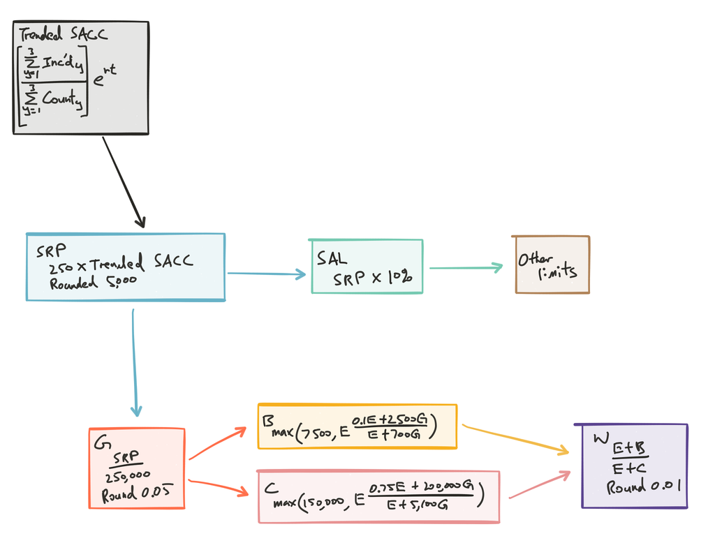

alt text

#### Lookup Based Process Map

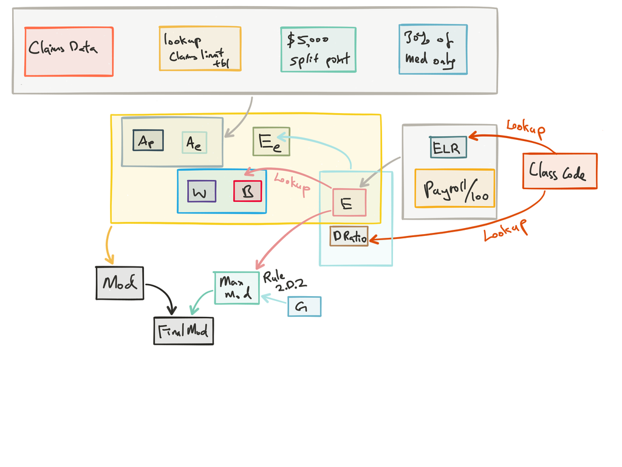

alt text

#### Trended State Average Cost per Claim SACC

$\text{Trended SACC} = \left( \dfrac{\sum\limits_{y=1}^3 \text{Inc'd Loss}_y}{\sum_{y=1}^3 \text{Claim Count}_y} \right) \times e^{rt}$

Rationale:

- Undeveloped losses so data has = maturity as the data that is used for actual losses entering the E-mod calculation
- Trend to bring older data to current cost level

Gillam, written in 1992, states there is no per-claim limit applied to losses in the G calculation. The NCCI manual written after 1998 states (rule D.2) that G is calculated using losses used in experience rating; suggesting limitations do apply (e.g. include 30% of medical only).

#### State Reference Point (SRP)

$SRP = 250 \times \text{Trended SACC}$

Additional adjustments/constraints:

- **Round** to nearest $5,000
- $SRP_t \nless SRP_{t-1}$ unless significant reduction in WC benefits
- $\Delta SRP > 20\%$ will be investigated

#### State Accident Limit (SAL)

Limit for individual actual losses entering the experience mod calculation

$SAL = 10\% \times SRP$

Other dependents:

- Limit on the total losses from a multiple claim occurrence = $2 \times SAL$
- See rule 2.C.13

#### Scale factor (G)

$G = \dfrac{SRP}{250{,}000}$

Additional adjustments/constraints:

- **Round** to nearest 0.05

$> +20%$ change will be investigated; Similar to SRP, can’t decrease

#### Ballast (B), Weighting Value (W) and C

Ballast (B), Weighting Value (W) (and C = $K_e$)

$\begin{array}{llll} B &= \max \left( 7500, \: E \times \dfrac{0.1E + 2{,}500G}{E + 700G} \right) &= K_p & B>0 \\ C &= \max \left( 150{,}000, \: E \times \dfrac{0.75E + 200{,}000G}{E + 5{,}100G} \right) &= K_e \\ \end{array}$

$W = \dfrac{E + B}{E + C}$

Additional adjustments/constraints:

- **Round** to nearest 0.01
- $0 < W <1$
- $W$ can **not** $\uparrow$ for $\downarrow$ $E$

Constraint on $B$ and $W$ so that no risk has 100% credibility

### Plan Rating Values

Need *ELRs* and *D-ratios* for each class $i$ to get $E$ and $E_e$

$E_i = ELR_i \times \left( \dfrac{\sum\limits_{y=1}^3 Payroll_{i,y}}{100} \right)$

$E = \sum\limits_{i \in class} E_i$

$E_p = \sum\limits_{i \in class} D_i \times E_i$

$E_e = E - E_p$

ELRs and D-Ratios are calculated at the same time and using the same data as the filed rates

#### Expected Loss Ratio by Class:

$ELR_i$ Expected Loss Ratio by Class

*Step 0. Starting Point*

Class rates (or class loss costs) published by NCCI (by States)

*Step 1. Calculate ELR Level Factor*

Purpose:  
Reduces manual rates (or loss costs) to pure premiums at 2nd report, @ the same benefit level as in the experience period

Calculations/Adjustments:

1. Class rate (or loss costs) $\times PLR$  
   Remove remove profit, taxes, and expenses
2. Time frame difference adjustments between prospective class rates and historical losses  
   Benefit levels, loss development, trend

*Step 2. ELR factors by HG and ELR factors by class*

Purpose:  
To reflect that losses going into the experience rating calculation are limited by the $SAL$, but the losses underlying the rates are not limited

Calculations/Adjustments:

1. $\forall$ HG: $\dfrac{\sum\limits_i Cost_{i,j}}{\sum\limits_i Claim_{i,j}}$ $j \in \{\text{Serious Injury Types}\}$
2. $\forall$ types, HG: $\dfrac{SAL}{\text{injury type average cost per case}} = \text{Entry Ratio} \: r$
3. Use $r$ from 2. and tables of $R(L)$ $\Rightarrow$ $R(L)$ $\forall$ injury type and HG
4. $\forall$ HG: weight the 3 $R(L)$ by injury type weights to get a single $R(L)$ for each HG
5. $[\text{HG adjustment factor}] = 1 - R(L)$ from 4.
6. $\forall$ HG $[ELR \text{ level factor}]_{HG} \times [\text{HG adjustment factor}] = [\text{HG }ELR\text{ Factor}]$
7. $[\text{HG }ELR\text{ Factor}] \times \text{Class rate in HG} = ELR\text{ by class}$

$ELR_i = (\text{Manual Rate}_i) \times (\text{ELR level factor}_i) \times (\text{HG Adj Factor}_i)$

*Step 3. Check the ELRs for reasonability*

Not in syllabus

?Question? Use the value of E in the NCCI tables to find the values for W and B. (from 2011 Q15)

#### D-ratios by Class

Calculation not in syllabus

$D_i$ D-ratios by Class

Portion of loss that will be primary

1. Use 3 most recently available years of data
2. Calculate expected primary percentage of losses for serious, non-serious, and medical claim types
3. Weight the 3 together to produce a single D-ratios for each class

## Application of NCCI Experience Rating Plan

$\text{Standard Premium} = \text{Experience Mod} \times \sum\limits_{i \in class} \sum\limits_{j \in locations} \text{Manual Premium}_{i,j}$

Mod only differentiates loss potential for risks within a class, not between classes since it’s applied to the manual premium which varies by class

Debit and credit could just means a poor class fit and not necessary poor safety habits

## The Off-balance

Rate level vs premium level:

- Rate level: just manual premium
  - No Exp/Sch rating, prem discount, retro rating, dividends
- Premium level: includes all the above
  - Premium level can $\Delta$ due to $\Delta$ in any one of the above factors without rate level $\Delta$

$\begin{array} \text{Off-Balance} &= \dfrac{\text{Standard Premium}}{\text{Manual Premium}} \\ &= \text{weighted average experience mod across all risks} \\ &= f(\text{Adequacy of the rating values of the ELRs and D-ratios}) \end{array}$

If ELRs and D-ratios adequate:

- Off-Balance $\approx$ 1; or
- Slight credit (< 1.00) since risks large enough for experience rating tend to have better loss experience

Off-balance is not used to change the overall premium adequacy

- Varies by state, usually within $\pm$ 1-2 points of 1.00

If the off-balance isn’t changing, it has no impact on the needed premium level change

**Off-balance mismatch:**  
2013

- Due to the fact that rate indications are based on standard loss ratios, but the rate changes are applied to the manual rates
- Usually happens when rate adequacy deteriorates for several years due to lack of regulatory approval
- Example:
  1. DOI refuses to approve NCCI class rate level $\Delta$ (Individual E-mod $\uparrow$) $\Rightarrow$ rates are considered 10% inadequate (This is starting point for $E$)
  2. Off-balance $\uparrow$ > 1, since the $E$ values are too low relative to the A values; reduce the premium inadequacy, but not the rate inadequacy
  3. Rate indications are based on standard loss ratios, the indications will be too low compare to real inadequacy since the off-balance is reducing the premium inadequacy
  4. If adequate rates are then approved by the DOI, the off-balance will move back down towards 1, and the premiums will become inadequate once again
- Example 2:
  1. Projected LR to determine indication = $\dfrac{\text{Projected Losses}}{\text{Projected Final Premium (w/ e-mod)}}$
  2. Indication = $+x\%$
  3. DOI approve $+x\%$
  4. ELR used to get the $\mathrm{E}[L]$ in the Exp rating formula is based on manual rates $\Rightarrow$ $\mathrm{E}[L]$ in the mod formula $\uparrow$
  5. Mod formulas now compare actual losses vs higher $[L] $\Rightarrow$ Mod for individual risk start coming down $\Rightarrow$ Average mod $\downarrow$ (off-balance)
  6. Mods $\downarrow$ %$ Premium collected $\downarrow$ $\Rightarrow$ Premium inadequate

From [TIA](http://www.theinfiniteactuary.com/mb/viewtopic.php?f=17592&t=23387&sid=1cf6ce84b3b9097eb43584801adb56de)

- Indicated rate change factor = Actual Loss Ratio / Target Loss Ratio
- Where Actual Loss Ratio = Actual Losses / Final Premium and the Final Premium includes experience mods (i.e., the off-balance), among other things
- So as long as final premium doesn’t change, the rate indication doesn’t change (all else being equal). However, when the off-balance changes, the final premium will change, and thus the indication will change
- Looking at this from the opposite direction, after a rate change, the off-balance changes (since the expected losses in the experience mod formula are based on current rates). The changing off-balance causes the final premium to change yet again, which alters the rate indication.

## Using the NCCI Experience Rating Plan Manual

2002 Q33, 2009 Q25

Some highlights

### Rule 2.A.2.

Important

Table showing the premium **eligibility for experience rating** by **state**

Mod is *mandatory* once an insured is eligible

Need one of the following:

- $\sum\limits_{t=1}^2 \text{Manual Premium}_t \geq \text{Column A}$; OR
- $\dfrac{\sum\limits_{t=1}^3 \text{Manual Premium}}{3} \geq \text{Column B}$

### Rule 2.C

Descriptions of all the items in Experience mod formula

**2.C.9** and **2.C.10.** shows calculation for *interstate* $W$ and $B$

### Rule 2.C.13.

Important

Rules for different loss limits to apply to actual losses

Per claim accident limitation = $SAL$

Application is different depending whether it exceed the multi and single limit

- There are single and multiple claims limit
- The dollar amounts limit is under ther weighting values table

### Rule 2.D.1.

Important

Experience Mod Formula

### Rule 2.D.2.

Important

Maximum debit mod, varies by risk

### Rule 5.B.

Ex-Med coverage, formula to convert expected losses to an ex-medical basis

### Appendix Table

Important

Table for **ELRs** and **D-ratios** by class for AL

Table for $W$ values based on $E$ for AL * Also has $G$ and various loss limits and **state multi limit**

Table for $B$ values based on $E$ for AL

### Miscellaneous Rules

**Rule 1.C.8.**

Reasons why risk might have mod = 1.00

**Rule 2.A.5.**

Qualification for interstate experience rating

**Rule 2.B.2.**

Rating effective dates for multiple policy risks with different effective dates

**Rule 3.**  
2001 Q25

Ownership changes and combination of entities when they share common majority ownership

**Rule 4.B.1-3**

Corrections for payroll, losses of classifications can result in revised mods

**Rule 4.C.**

Definitions for preliminary, final, and contingent mod